# Final Project Group 2 No Code

Donald Rogers, Brannan Kovachev, Jeremy Wright

2022-11-17

# Part 1

### Introduction

Our group decided to do a project examining the role that Green Energy plays within the US and how emissions from energy generation can affect the population surrounding them. My focus was on more generalized information, especially looking at the US from a country-wide scale. To start, I first examined how energy was generated in the US.

#### Question 1: What is the historical trend for clean energy since 2001 in the US?

First, I generated a line graph detailing the different amounts of energy producers within the US. The dataset had data from 2001-2022, but the 2022 data was incomplete, so the graphs only show up until 2021. This visualization only takes into account the total amount of facilities devoted to each resource, instead of total power generated, but provides a good idea of how our country’s energy footprint has changed over the years.

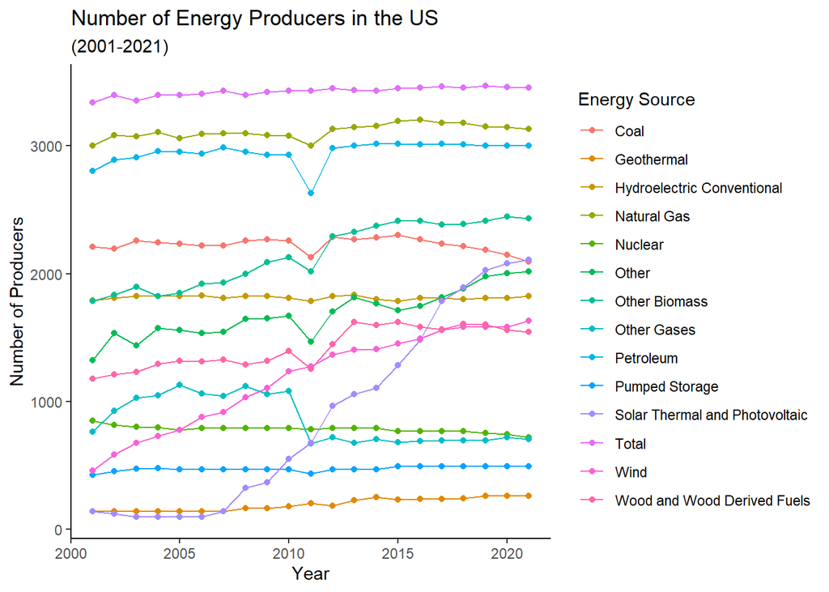

As can be seen above, energy producers based off of fossil fuels (or “Brown Energy”) are still dominant, with natural gas and petroleum topping the charts, but there have been increases to the amount of green energy producers, especially since 2010. Next, let’s filter out the brown energy sources so that we can see their trends better.

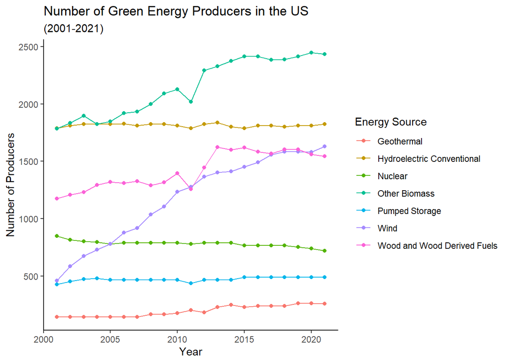

#### Question 2: What types of energy are most efficient within the United States?

Moving to possibly answer the previous question, I next examined which forms of energy were the most efficient, in terms of generating the least amount of pollutants per Megawatt hour of electricity. To provide some contest, an average American household uses about 10 MWh of power per year. The dataset also has emissions separated into three different types. They are Carbon Dioxide, Sulfur Dioxide, and Nitrogen Oxides (NO and NO2). To give a frame of reference for the amount of pollutants generated, driving a car for a year will generate about 4.5 metric tons of CO2. Sulfur Dioxide and Nitrogen Oxides are much more harmful than CO2, and are generated much less frequently than CO2 by consumers. Moving to the visualizations, I first found how many Megawatt hours of energy were generated per state in 2018 (2018 was the most recent year there was data for within the dataset), then how many metric tons of CO2, SO2, and NOx were generated per state in 2018. After joining the two datasets together, the following table was created.

Power Generation and Emissions

| State | Source | MWh Generated | Gas Emissions (Metric Tons) CO2 | Gas Emissions (Metric Tons) SO2 | Gas Emissions (Metric Tons) NOx |
| --- | --- | --- | --- | --- | --- |
| AK | Coal | 1257128 | 2700198 | 3040 | 4426 |
| AK | Hydroelectric Conventional | 3328450 | NA | NA | NA |
| AK | Natural Gas | 5895805 | 2774752 | 12 | 19076 |
| AK | Other | -6200 | NA | NA | NA |
| AK | Other Biomass | 90948 | 0 | 38 | 992 |
| AK | Petroleum | 1618558 | 1304152 | 2140 | 13414 |
| AK | Wind | 310030 | NA | NA | NA |
| AK | Wood and Wood Derived Fuels | 0 | NA | NA | NA |
| AL | Coal | 63555040 | 61108096 | 24242 | 30490 |
| AL | Hydroelectric Conventional | 22286278 | NA | NA | NA |
| AL | Natural Gas | 117600837 | 51005388 | 260 | 19686 |
| AL | Nuclear | 78925654 | NA | NA | NA |
| AL | Other | -98 | NA | NA | NA |
| AL | Other Biomass | 75344 | 0 | 0 | 908 |
| AL | Other Gases | 9608 | 0 | 4 | 742 |
| AL | Petroleum | 131407 | 166042 | 172 | 234 |
| AL | Solar Thermal and Photovoltaic | 714504 | NA | NA | NA |
| AL | Wood and Wood Derived Fuels | 6817414 | 0 | 50134 | 11078 |
| AR | Coal | 59992202 | 58655136 | 94742 | 37820 |
| AR | Hydroelectric Conventional | 6017550 | NA | NA | NA |
| AR | Natural Gas | 41247410 | 17938780 | 102 | 6562 |
| AR | Nuclear | 25441636 | NA | NA | NA |
| AR | Other | 10174 | 33264 | 356 | 62 |
| AR | Other Biomass | 149900 | 0 | 26 | 1536 |
| AR | Petroleum | 71034 | 71726 | 86 | 34 |
| AR | Pumped Storage | 80490 | NA | NA | NA |
| AR | Solar Thermal and Photovoltaic | 406826 | NA | NA | NA |
| AR | Wood and Wood Derived Fuels | 2581480 | 0 | 23058 | 6392 |
| AZ | Coal | 61489246 | 61795004 | 29694 | 51414 |
| AZ | Hydroelectric Conventional | 13964484 | NA | NA | NA |
| AZ | Natural Gas | 74336150 | 31639520 | 222 | 23306 |
| AZ | Nuclear | 62194518 | NA | NA | NA |
| AZ | Other | -5072 | NA | NA | NA |
| AZ | Other Biomass | 74750 | 0 | 0 | 1046 |
| AZ | Petroleum | 99892 | 78600 | 12 | 48 |
| AZ | Pumped Storage | -9052 | NA | NA | NA |
| AZ | Solar Thermal and Photovoltaic | 10280753 | NA | NA | NA |
| AZ | Wind | 1060380 | NA | NA | NA |
| AZ | Wood and Wood Derived Fuels | 364240 | 0 | 50 | 196 |
| CA | Coal | 562656 | 2719364 | 654 | 1570 |
| CA | Geothermal | 23353682 | 614352 | 0 | 0 |
| CA | Hydroelectric Conventional | 52661333 | NA | NA | NA |
| CA | Natural Gas | 179208948 | 83144784 | 378 | 83738 |
| CA | Nuclear | 36427038 | NA | NA | NA |
| CA | Other | 1657536 | 551118 | 672 | 1102 |
| CA | Other Biomass | 5647697 | 0 | 34 | 39868 |
| CA | Other Gases | 2907920 | 0 | 16 | 3778 |
| CA | Petroleum | 137756 | 128118 | 202 | 1096 |
| CA | Pumped Storage | -297148 | NA | NA | NA |
| CA | Solar Thermal and Photovoltaic | 53970362 | NA | NA | NA |

The previous table showed only the first 50 observations and with over 500 observations in total, there’s not much purpose to putting all of them in one table. So, since we are focusing on the entire US, let’s look at the totals for the entire US to get a good idea of what energy source is the most efficient.

US Total Power Generation and Emissions

| State | Energy Source | MWh Generated | Gas Emissions (Metric Tons) CO2 | Gas Emissions (Metric Tons) SO2 | Gas Emissions (Metric Tons) NOx |
| --- | --- | --- | --- | --- | --- |
| US | Total,Coal | 2291924383 | 2340396682 | 2405118 | 1566792 |
| US | Total,Geothermal | 31934268 | 840078 | 0 | 0 |
| US | Total,Hydroelectric Conventional | 585047978 | NA | NA | NA |
| US | Total,Natural Gas | 2937453247 | 1324805112 | 7664 | 789368 |
| US | Total,Nuclear | 1614168954 | NA | NA | NA |
| US | Total,Other | 25946409 | 28154278 | 39750 | 70790 |
| US | Total,Other Biomass | 41791530 | 0 | 2828 | 253370 |
| US | Total,Other Gases | 26925497 | 0 | 1446 | 52768 |
| US | Total,Petroleum | 50451278 | 54496090 | 149992 | 82530 |
| US | Total,Pumped Storage | -11809078 | NA | NA | NA |
| US | Total,Solar Thermal and Photovoltaic | 127650645 | NA | NA | NA |
| US | Total,Wind | 545299578 | NA | NA | NA |
| US | Total,Wood and Wood Derived Fuels | 82010618 | 0 | 536056 | 154764 |

As the table shows, there are many different types of energy that don’t have any emissions recorded for those types of power plants. This is to be expected, as many of these sources don’t generate any emissions since they don’t require anything to be burnt to generate power. Nuclear, while appearing to generate emissions, only generates steam, since the nuclear reactions in the core of the plant are just used to heat water and don’t make any gases by themselves. So, to answer the question of which energy generation is the most efficient (in terms of amount of emissions), we have our answer: Hydroelectric, Nuclear, Solar, Thermal, Photovoltaic, and Wind. I didn’t include Pumped Storage, as the table shows that we actually lose power in total when using pumped storage. To see which forms of energy that create emissions are most efficient, all of the sources with no emissions were dropped for the next table.

US Total Power Generation and Emissions

| State | Energy Source | MWh Generated | Gas Emissions (Metric Tons) CO2 | Gas Emissions (Metric Tons) SO2 | Gas Emissions (Metric Tons) NOx |
| --- | --- | --- | --- | --- | --- |
| US | Total,Coal | 2291924383 | 2340396682 | 2405118 | 1566792 |
| US | Total,Geothermal | 31934268 | 840078 | 0 | 0 |
| US | Total,Natural Gas | 2937453247 | 1324805112 | 7664 | 789368 |
| US | Total,Other | 25946409 | 28154278 | 39750 | 70790 |
| US | Total,Other Biomass | 41791530 | 0 | 2828 | 253370 |
| US | Total,Other Gases | 26925497 | 0 | 1446 | 52768 |
| US | Total,Petroleum | 50451278 | 54496090 | 149992 | 82530 |
| US | Total,Wood and Wood Derived Fuels | 82010618 | 0 | 536056 | 154764 |

As we can see from the remaining fuels, most of the emissions created in the US come from Brown Energy, such as Coal and Natural Gas, which also account for a majority of the energy created. Before doing any calculations, we can see that Natural Gas is much more efficient than Coal when it comes to emissions, as there were more MWh generated by Natural Gas sources yet less emissions in every category. Some forms of Green Energy (such as Wood, Biomass, and Geothermal) are still found in this table since they produce some forms of emissions, but not in all three categories.

Carbon Dioxide Generation per Megawatt Hour

| State | Energy Source | Tons CO2/MWh |
| --- | --- | --- |
| US | Total,Geothermal | 0.0263065 |
| US | Total,Natural Gas | 0.4510047 |
| US | Total,Coal | 1.0211492 |
| US | Total,Petroleum | 1.0801726 |
| US | Total,Other | 1.0850934 |

Sulfur Dioxide Generation per Megawatt Hour

| State | Energy Source | Tons SO2/MWh |
| --- | --- | --- |
| US | Total,Natural Gas | 0.0000026 |
| US | Total,Other Gases | 0.0000537 |
| US | Total,Other Biomass | 0.0000677 |
| US | Total,Coal | 0.0010494 |
| US | Total,Other | 0.0015320 |
| US | Total,Petroleum | 0.0029730 |
| US | Total,Wood and Wood Derived Fuels | 0.0065364 |

Nitrous Oxides (NO and NO2) Generation per Megawatt Hour

| State | Energy Source | Tons NOx/MWh |
| --- | --- | --- |
| US | Total,Natural Gas | 0.0002687 |
| US | Total,Coal | 0.0006836 |
| US | Total,Petroleum | 0.0016358 |
| US | Total,Wood and Wood Derived Fuels | 0.0018871 |
| US | Total,Other Gases | 0.0019598 |
| US | Total,Other | 0.0027283 |
| US | Total,Other Biomass | 0.0060627 |

#### Question 3: Which US States generate the most energy?

This question was relatively straightforward, as I wrangled one of our datasets to group the MWh generated by state in 2021 (most recent year with complete data). I put the data into a Choropleth Map, which can be seen below.

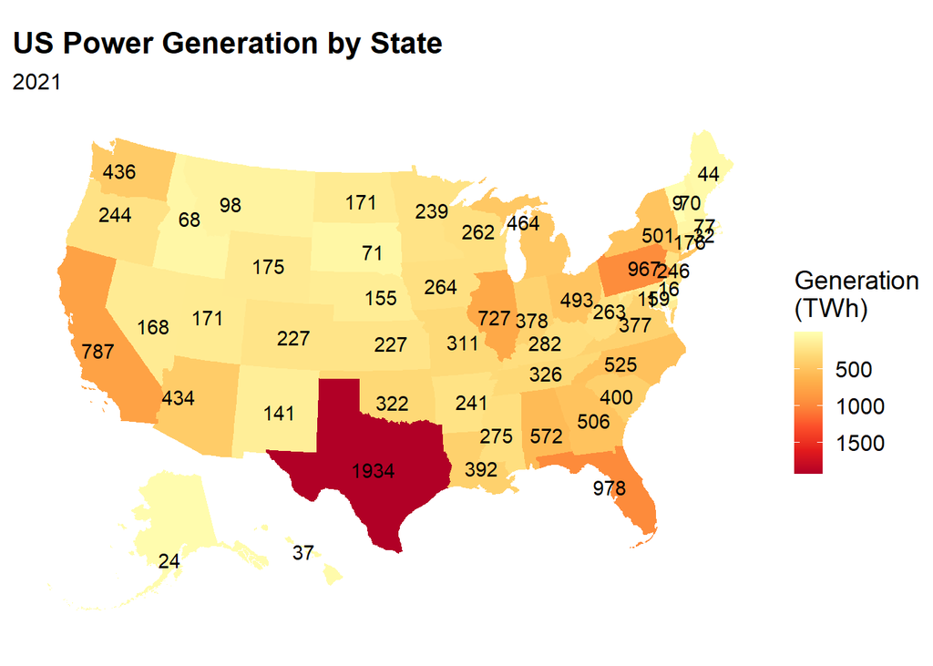

Looking at the map, the answer to the question becomes obvious. Texas, by almost double, generates the most power in the entire US. The EIA reports that most of this huge power draw is based off of their industrial sector, accounting for over half of their total power generation. This begs the question, has Texas always been the most power hungry state? Going back to 2001, and jumping 5 years each time, the following choropleths are generated.

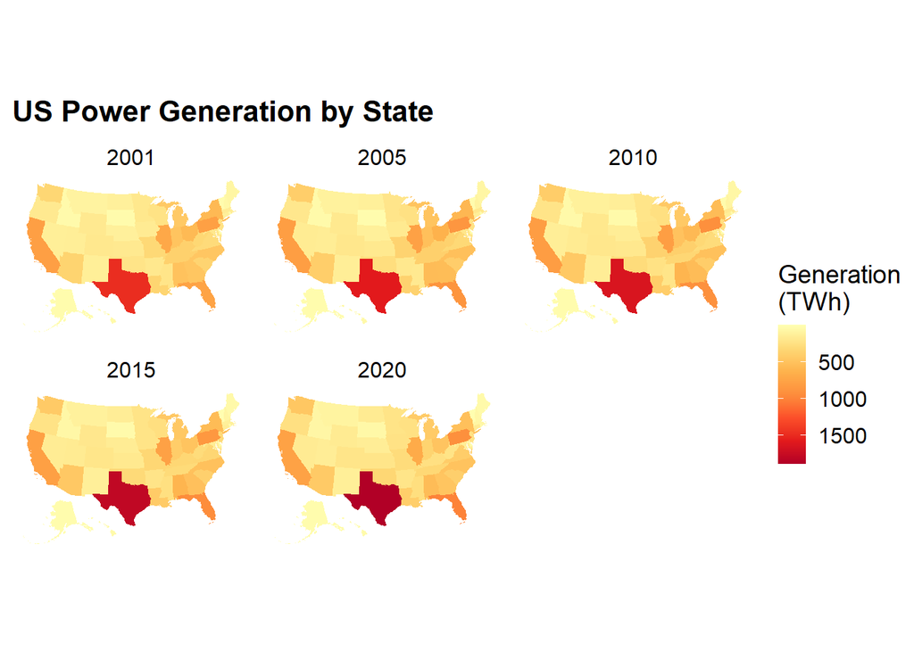

After looking at these choropleths, we can see that Texas has been far ahead of every state in terms of power generation for the last 20 years, and has only been increasing the amount of power generated in each subsequent year. Looking at the map, most states seem to be generating more power as we progress through the 21st Century, but the general ranking of highest producers seems to be consistent, with Texas at the top, and California, Florida, Illinois, and Pennsylvania being right behind. The top of the Northeast (above New York) seems to generate the least amount of power per state, with all of the states falling behind the Southeast and Midwest, but the West, save california, Arizona, and Washington doesn’t seem to be much higher.

### Conclusion

# Part 2

#### Introduction

As a whole, my team is looking at various trends and relationships with regards to supplying electric power in the United States. Rather than looking at the U.S. in general, my part of the project is about zooming into one of the largest states, California, and looking at the emissions produced in the pursuit of supplying electricity. First, I will visualize the emissions produced by each county. Using this wrangled data, I will then examine the relationship between a county’s change in population and its quantity of emissions. Finally, I will compare the Demographics of various counties based on how bad their emissions are in order to determine if any groups are disproportionately suffering the effects of emissions.

#### Question 1: What is the distribution of emissions due to the supply of electric power across California counties?

We will begin by creating a heat map of the emissions of each county across California. However, we should be specific about what type of emissions we care about. I am interested in the emissions as related to the supply of electric power. While power plants certainly play a hand in this, they are not the only source of such emissions. As such, I have used a data set which contains site locations, their emissions, and a ‘NAICS Code’ among a few other variables. Most notably, this NAICS Code will be how we identify locations related to supplying electric power. Without going into too much detail, a NAICS code is self assigned by a company based on what industry they are a part of. Each code is built using sets of digits where more digits are added when more specificity is required. This allows us to be as general or specific as we like in terms of which industry(s) and sector(s) we target. For my purposes, I am using code ‘2211’ which includes all “Electric Power Generation, Transmission, and Distribution” company sites. This allows me to capture the full breadth of emissions from sites in California related to supplying electric power. Here is the choropleth of such site’s emissions in California:

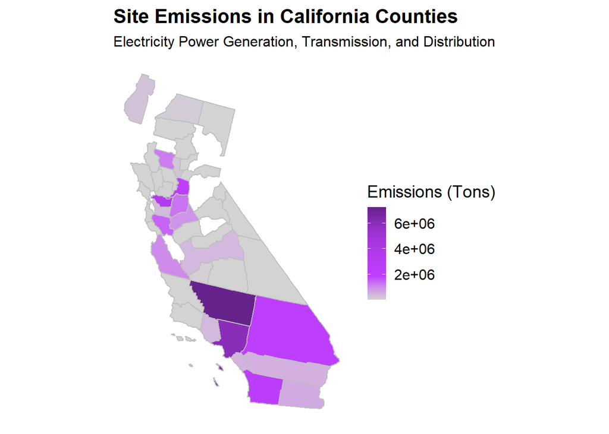

The emissions in the state seem to be congregated around two nodes. The northern node includes the Eastern Bay Area and some of the northern Central Counties while the southern node is generally encompassed by Southern Counties, most notably Kern and Los Angeles. Other than those clusters, the remaining counties have much fewer emissions with a number not even appearing as they lack emissions entirely.

Based on a hunch and global trends, let’s take a look at the heatmap of the population in each of California’s counties:

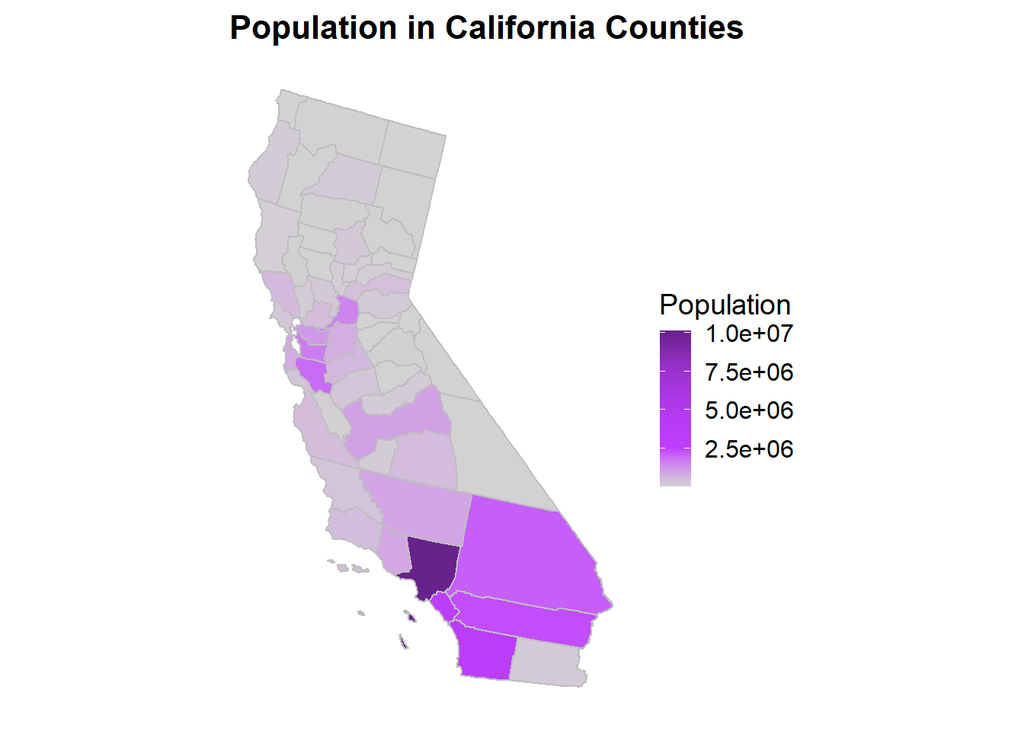

Indeed, it’s relatively close to what one might suspect. The two nodes seem similar with one near the Bay area and one Near Los Angeles. However, the actual relative magnitude of the particular counties does look different. For example, when we were looking at the emissions, Kern was the darkest shaded county in the southern node. However, in creating a heat map of population, we see that Los Angeles has the most individuals within its borders. This leads us to conclude that there is certainly a positive association between emissions and raw population but not 1:1 correlation.

Related to this question, though mostly pursued out of curiosity, I was interested in seeing if there was a noticeable clustering of sites in these two nodes or if the emissions were perhaps being produced by a few, very substantial sites. In order to visualize this question, I created the following Leaflet:

[interactive chart not shown]

As we can see, there does seem to be many sites clustered in these regions. It is not just the act of a few very bad emitters that cause this concentration of emissions. You can even hover over each location to see that they are individually named and independent sites.

#### Question 2: What is the trend between population change and a county’s emissions?

I was interested in determining whether counties with large amounts of emissions had a relatively faster decreasing population. The detail about ‘relatively faster’ is important as I am not looking at if their population decreased **at all**. No, instead, I want to know whether it is decreasing (or perhaps increasing) faster than other counties in California. We need to properly make this comparison as otherwise we might correlate a statewide decrease in population with emissions when in fact there are a host of economic reasons California has had for in increasing number of citizens emigrating from the state. Ultimately, My hypothesis was that counties with more emissions would have a population increasing more slowly or entirely decreasing when compared to those with less emissions.

In order to determine this, I got each county’s rank in terms of quantity of emissions and in terms of average population change over the past five years. I then plotted these two ranks and drew a best fit line to see the direction of correlation:

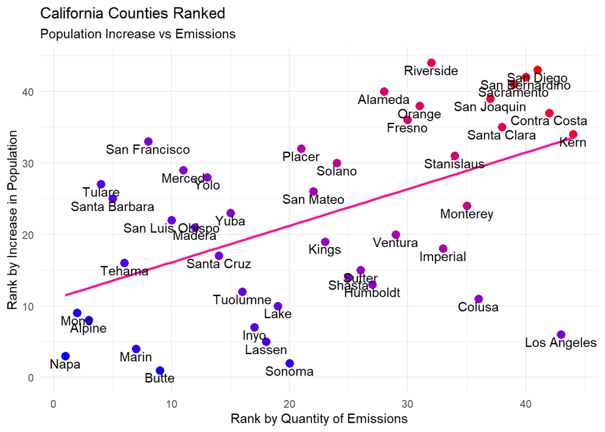

As evident by the chart, it turns out that the greater emissions you have, the more positive your population change is. This makes sense as it is a normal trend of population clusters around the world. Simply, if you have more people coming in, you’ll need more energy for them and thus will create more emissions when supplying that energy. It seems that the pollution in and around these regions is not bad enough yet to convince individuals to move elsewhere.

#### Question 3: What are the demographics in the counties with the most emissions?

Finally, I was interested in determining if the emissions from power generation were disproportionately affecting underrepresented demographic groups. In order to determine this, I started by making a list of the top 10 counties which produce the most emissions. I also got data about the demographics of all the counties in California. Using this demographic information, I found the average percent representation of each demographic across all of California. This “average percent” value is important as I used it to find the percentage point difference between a demographic across all of California and its specific representation in each of the top 10 emitting counties. Rephrasing this statement for clarification; I found the difference of a demographic’s percent representation statewide and its representation in the top 10 emitting counties. I was then able to create a column chart of this “difference from Average Representation” value and each of the Demographics, faceting it by county:

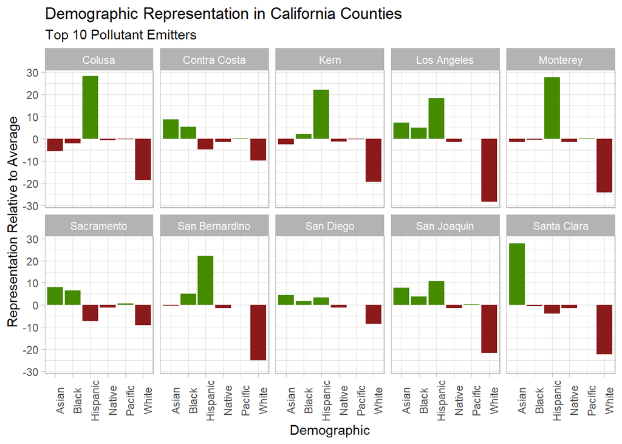

Out of curiosity about confirming the above mentioned trends, I took the average of each Demographics representation in these 10 counties and found the difference from the state wide mean in order to produce the following chart:

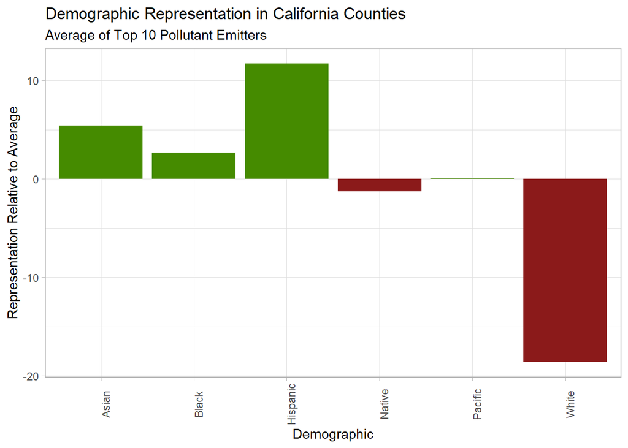

Though it is a much smaller, simpler visualization, I think this bar chart makes the truth self-evident. Demographics which are underrepresented statewide have to suffer the worst emission pollution across California’s counties.

Seeing the relative Demographic representation in each of the top 10 worst polluting counties, I was curious about the same distribution in the 10 counties which pollute the least:

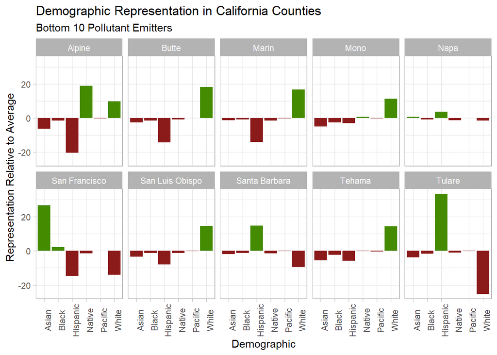

At first glance, this chart seems nearly the inverse of the previous, but personally I was surprised that there were still such large negative measurements for the white demographic. After all, it can’t be that every county is less than the state average, right? Right. It turns out that the above visualization is of the counties with the least emission *as long as they still had emissions*.

Instead, lets take a look a the counties with truly the fewest emissions. Those with absolutely none:

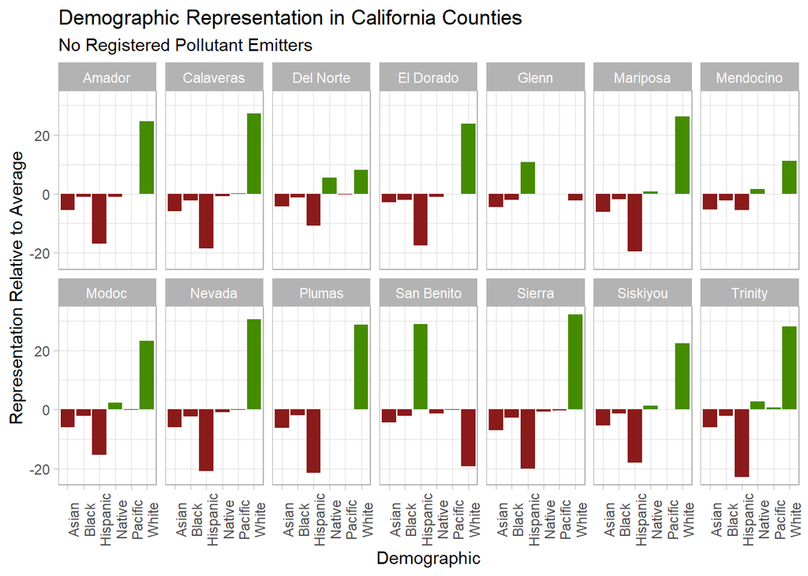

Now we can really see the truth of the matter. Every single county (baring 2 of 14) which don’t produce emissions in California is dominated by white representation. The only counties that are not dominate by white representation are dominated by the Hispanic demographic, and this is likely as it is a cultural hub for this group. In fact, other than San Benito and Glenn (the counties dominated by the Hispanic demographic), the three underrepresented groups of Asian, Black, and Hispanic are all entirely in the red. If it wasn’t evident before, it should be clear now that certain demographics suffer the pollution of emissions far worse than others.

Finally, as we’ve been look at the percent difference from the state mean this whole time, I was curious about seeing the raw percent representation of each demographic across these two extremes. Below I have created two tables. The first is of the top 10 counties with the most emissions, and the second is of those counties with no emissions:

| County | Asian | Black | Hispanic | Native | Pacific | White |
| --- | --- | --- | --- | --- | --- | --- |
| Colusa | 1.5 | 0.9 | 58.4 | 1.1 | 0.1 | 36.3 |
| Contra Costa | 15.8 | 8.3 | 25.3 | 0.2 | 0.5 | 44.9 |
| Kern | 4.5 | 5.1 | 52.2 | 0.5 | 0.1 | 35.4 |
| Los Angeles | 14.3 | 7.9 | 48.4 | 0.2 | 0.2 | 26.5 |
| Monterey | 5.6 | 2.5 | 57.9 | 0.2 | 0.5 | 30.6 |
| Sacramento | 15.1 | 9.5 | 22.8 | 0.4 | 1.1 | 45.7 |
| San Bernardino | 6.7 | 8.0 | 52.3 | 0.3 | 0.3 | 29.8 |
| San Diego | 11.5 | 4.7 | 33.4 | 0.4 | 0.4 | 46.2 |
| San Joaquin | 14.8 | 6.7 | 40.8 | 0.2 | 0.5 | 33.2 |
| Santa Clara | 34.9 | 2.4 | 26.1 | 0.2 | 0.3 | 32.6 |

| County | Asian | Black | Hispanic | Native | Pacific | White |
| --- | --- | --- | --- | --- | --- | --- |
| Amador | 1.5 | 2.0 | 13.2 | 0.7 | 0.2 | 79.3 |
| Calaveras | 1.2 | 0.6 | 11.5 | 0.9 | 0.5 | 82.0 |
| Del Norte | 2.7 | 1.8 | 19.2 | 7.2 | 0.1 | 62.8 |
| El Dorado | 4.2 | 0.9 | 12.6 | 0.6 | 0.2 | 78.5 |
| Glenn | 2.6 | 0.8 | 40.8 | 1.7 | 0.3 | 52.5 |
| Mariposa | 1.0 | 1.2 | 10.6 | 2.4 | 0.3 | 81.0 |
| Mendocino | 1.7 | 0.6 | 24.5 | 3.3 | 0.2 | 65.9 |
| Modoc | 1.1 | 0.7 | 14.6 | 4.0 | 0.1 | 78.0 |
| Nevada | 1.1 | 0.5 | 9.2 | 0.7 | 0.1 | 85.4 |
| Plumas | 0.8 | 0.9 | 8.5 | 1.8 | 0.3 | 83.5 |
| San Benito | 2.7 | 0.7 | 58.9 | 0.3 | 0.2 | 35.6 |
| Sierra | 0.0 | 0.1 | 10.1 | 1.0 | 0.0 | 87.0 |
| Siskiyou | 1.6 | 1.5 | 12.0 | 2.9 | 0.3 | 77.2 |
| Trinity | 1.1 | 0.8 | 7.2 | 4.3 | 0.9 | 82.8 |

Even without getting into the nuance of difference from the state mean, we can at a glance come to similar conclusions as before. I would even argue that seeing the magnitude of each county’s demographic breakdown makes the situation seem even more self-evident.

#### Conclusion

Overall, the conclusions we can come to about California’s emissions in relation to electricity supply are relatively standard and unfortunately too common. It produces more emissions near it largest population centers: Los Angeles and the Bay Area. As the population of a region changes more positively, it tends to have greater emissions. Finally, demographics which are underrepresented statewide must suffer the worst of the pollution from emissions. Though it would be very challenging and there are many practical difficulties, it may one day be useful to consider decoupling these trends. California is just one state, but these trends have been spoken about as a worldwide phenomenon. Eventually, populations will suffer too much from pollution. We will need to find a way to limit or remove the contaminates from our largest centers of civilization if we hope to for a better future.

### Section 3 - Jeremy

## Question 1: What counties in CA generate the most power, and which ones consume the most power?

To answer this question, we are going to use 5 different data sets. The first dataset, powerplants, contains the name, latitude, longitude, fuels, and power generation of many different power plants. However, we are interested in the counties the power plants are located in. Thus, we are going to use a shape file to determine where the power plants intersect with the counties.

The powerplants dataset was sourced from the following website: https://datasets.wri.org/dataset/globalpowerplantdatabase.

The process for finding the FIPS code from the latitude and longitude was sourced from the following website (with modifications for reduced overall code): https://shiandy.com/post/2020/11/02/mapping-lat-long-to-fips/.

The county shape files were sourced from the following website: https://www.census.gov/geographies/mapping-files/time-series/geo/carto-boundary-file.html.

```
## # A tibble: 5 × 10
##   country country_…¹ name  gppd_…² capac…³ latit…⁴ longi…⁵ prima…⁶ gener…⁷  fips
##   <chr>   <chr>      <chr> <chr>     <dbl>   <dbl>   <dbl> <chr>     <dbl> <int>
## 1 USA     United St… 1420… USA005…     1.3    33.8   -118. Solar      1.78  6037
## 2 USA     United St… 2081… USA005…     1.2    36.7   -119. Solar      1.54  6019
## 3 USA     United St… 2097… USA005…     1.5    37.4   -121. Solar      2.66  6047
## 4 USA     United St… 2127… USA005…     1.3    39.3   -122. Solar      2.41  6101
## 5 USA     United St… 2555… USA005…     1      34.0   -118. Solar      1.25  6037
## # … with abbreviated variable names ¹country_long, ²gppd_idnr, ³capacity_mw,
## #   ⁴latitude, ⁵longitude, ⁶primary_fuel, ⁷generation_gwh_2019
```

Now that we know what counties the power plants are in, we need to be able to map the counties. The third and fourth data sets give us the coordinates for the borders of California and the counties in California. However, the county co do not include the FIPS code though. Thus, we are going to use the county.fips package to find this last piece of information.

The California outline and the county outlines are sourced from the ggplot2 map_data function. The county.fips dataset is from the maps package.

```
##        long      lat group order     region subregion fips stateFIPS countyFIPS
## 1 -121.4785 37.48290   157  6965 california   alameda 6001         6          1
## 2 -121.5129 37.48290   157  6966 california   alameda 6001         6          1
## 3 -121.8853 37.48290   157  6967 california   alameda 6001         6          1
## 4 -121.8968 37.46571   157  6968 california   alameda 6001         6          1
## 5 -121.9254 37.45998   157  6969 california   alameda 6001         6          1
```

We have now wrangled most of the data we will be using for the power production half of the question. Next, we are going to compute the answer to our question.

Some of the steps done here are not necessary to answer the question, but they will provide us with interesting data to plot.

This is simply a table showing the answer to the question.

```
##       region       subregion fips stateFIPS countyFIPS primary_fuel
## 1 california            kern 6029         6         29 Total County
## 2 california     los angeles 6037         6         37 Total County
## 3 california san luis obispo 6079         6         79 Total County
## 4 california    contra costa 6013         6         13 Total County
## 5 california  san bernardino 6071         6         71 Total County
##   sumGenerationGWH_2019
## 1              29959.89
## 2              23378.14
## 3              18690.75
## 4              14164.07
## 5              11968.47
```

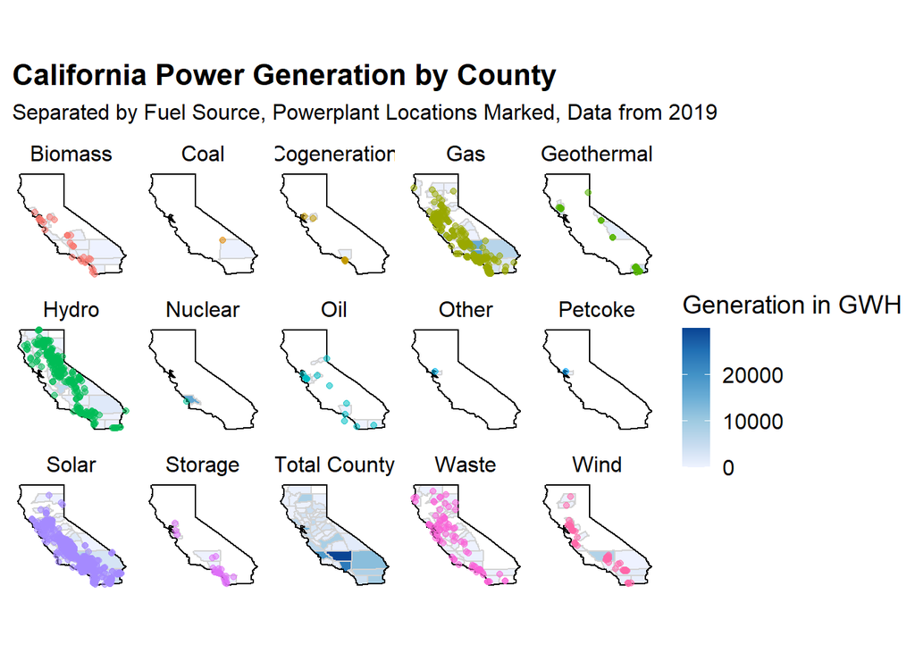

Prepare the data related to the consumption of power.

### Plotting power consumption

These are the 5 California counties that consume the most power.

```
##       region   subregion fips stateFIPS countyFIPS Sector     2019
## 1 california los angeles 6037         6         37  Total 66118.67
## 2 california      orange 6059         6         59  Total 19459.51
## 3 california   san diego 6073         6         73  Total 19047.67
## 4 california        kern 6029         6         29  Total 17105.08
## 5 california santa clara 6085         6         85  Total 16664.46
```

The graph of power consumption.

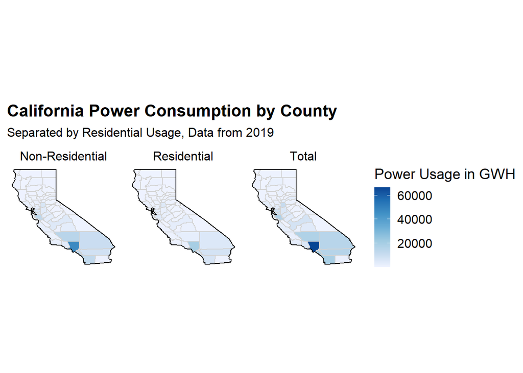